# Metagenome Report

# Sequencing run

**Total reads:** 37.739.644  
**Host reads:** 132.477 (0,35%)  
**Non-human reads:** 37.607.167 (99,65%)

Reads with poor quality and low-complexity regions were trimmed with fqtrim (Center for Computational Biology, Johns Hopkins University). Remaining high-quality reads were aligned against the human reference genome using bowtie2 (Langmead und Salzberg 2012). All non-human reads were subsequently further analyzed with various metagenomics tools.

# Kraken2

Showing top 30 results.

**k2_standard database**  
Unclassified reads: 1.801.974 (4,79%).  
Homo sapiens reads: 61591 (0,16%)

|  | Species | reads_clade | reads_taxon | minimizers | distinct_minimizers | ncbi_id |
| --- | --- | --- | --- | --- | --- | --- |
| 1 | Tick-borne encephalitis virus | 34626953 | 34626953 | 386442997 | 2826 | 11084 |
| 2 | Spanish goat encephalitis virus | 342931 | 342931 | 7557651 | 465 | 1691889 |
| 3 | Louping ill virus | 247668 | 247668 | 5829902 | 414 | 11086 |
| 4 | Langat virus | 112591 | 112591 | 1022336 | 45 | 11085 |
| 5 | Homo sapiens | 61591 | 61591 | 753078 | 40799 | 9606 |
| 6 | Saumarez Reef virus | 31608 | 31608 | 673723 | 7 | 40012 |
| 7 | Burkholderia contaminans | 13258 | 13258 | 128730 | 51636 | 488447 |
| 8 | Omsk hemorrhagic fever virus | 4026 | 4026 | 191471 | 104 | 12542 |
| 9 | Kyasanur Forest disease virus | 2786 | 2786 | 221676 | 28 | 33743 |
| 10 | Stutzerimonas stutzeri | 468 | 430 | 7055 | 5205 | 316 |

[output cut: 20 more lines]

**k2_viral database**  
Unclassified reads: 1.901.955 (5,06%).

|  | Species | reads_clade | reads_taxon | minimizers | distinct_minimizers | ncbi_id |
| --- | --- | --- | --- | --- | --- | --- |
| 1 | Tick-borne encephalitis virus | 34621546 | 34621546 | 386447857 | 2826 | 11084 |
| 2 | Spanish goat encephalitis virus | 342355 | 342355 | 7557652 | 466 | 1691889 |
| 3 | Louping ill virus | 247650 | 247650 | 5830722 | 415 | 11086 |
| 4 | Langat virus | 112642 | 112642 | 1022336 | 45 | 11085 |
| 5 | Saumarez Reef virus | 31642 | 31642 | 673723 | 7 | 40012 |
| 6 | Omsk hemorrhagic fever virus | 4025 | 4025 | 191471 | 104 | 12542 |
| 7 | Kyasanur Forest disease virus | 2784 | 2784 | 221676 | 28 | 33743 |
| 8 | Human alphaherpesvirus 1 | 277 | 277 | 3237 | 52 | 10298 |
| 9 | Human mastadenovirus C | 137 | 137 | 2593 | 52 | 129951 |
| 10 | Gadgets Gully virus | 82 | 82 | 1371 | 13 | 64307 |

[output cut: 20 more lines]

**k2_eupathdb48 database**  
Unclassified reads: 37.605.720 (100%).

|  | Species | reads_clade | reads_taxon | minimizers | distinct_minimizers | ncbi_id |
| --- | --- | --- | --- | --- | --- | --- |
| 1 | Paracoccidioides lutzii | 342 | 0 | 1598 | 6 | 1048829 |
| 2 | Paracoccidioides lutzii Pb01 | 342 | 342 | 1598 | 6 | 502779 |
| 3 | Acanthamoeba palestinensis | 80 | 80 | 330 | 28 | 28015 |
| 4 | Eimeria maxima | 50 | 50 | 245 | 17 | 5804 |
| 5 | Sarcocystis neurona | 50 | 50 | 465 | 93 | 42890 |
| 6 | Leptomonas pyrrhocoris | 37 | 37 | 159 | 25 | 157538 |
| 7 | Plasmodium cynomolgi | 35 | 35 | 44 | 4 | 5827 |
| 8 | Eimeria necatrix | 33 | 33 | 234 | 12 | 51315 |
| 9 | Sporothrix brasiliensis | 30 | 0 | 122 | 12 | 545650 |
| 10 | Sporothrix brasiliensis 5110 | 30 | 30 | 122 | 12 | 1398154 |

[output cut: 20 more lines]

# Centrifuge

Showing top 30 results.

|  | Name | taxID | taxRank | genomeSize | Reads | UniqueReads | abundance |
| --- | --- | --- | --- | --- | --- | --- | --- |
| 1 | Tick-borne encephalitis virus | 11084 | species | 3206714 | 56885066 | 27717891 | 0.963262 |
| 2 | Louping ill virus | 11086 | species | 84506 | 313117 | 14439 | 0.00044823 |
| 3 | Cloning vector pTBEV-32.11 ic | 1429999 | species | 14535 | 123141 | 0 | 1.89397e-29 |
| 4 | Guanarito mammarenavirus | 45219 | species | 270008 | 31018 | 8302 | 9.81518e-05 |
| 5 | Spanish goat encephalitis virus | 1691889 | species | 11126 | 25455 | 447 | 3.74462e-23 |
| 6 | Burkholderia contaminans | 488447 | species | 21249946 | 18333 | 11542 | 0.00012781 |
| 7 | Pan troglodytes | 9598 | species | 1084058817 | 11311 | 82 | 0 |
| 8 | Spanish sheep encephalitis virus | 41408 | species | 12496 | 11303 | 1669 | 1.00054e-13 |
| 9 | Kumlinge virus | 11092 | leaf | 1788 | 7118 | 359 | 0.002767 |
| 10 | Langat virus | 11085 | species | 45050 | 5764 | 0 | 1.46188e-53 |

[output cut: 20 more lines]

# Arriba

Viral alignment and genome coverage.

|  | VIRUS | GENOME_SIZE | COVERED_BASES | COVERED_GENOME_FRACTION | HIGH_QUALITY_ALIGNMENTS | RPKM |
| --- | --- | --- | --- | --- | --- | --- |
| 1 | NC_001672.1_Tick-borne_encephalitis_virus-complete_genome | 11141 | 11116 | 0.997756 | 46366324 | 40274.8 |

Detection of viral integrations into the human genome.

|  | X.gene1 | gene2 | strand1.gene.fusion. | strand2.gene.fusion. | breakpoint1 | breakpoint2 | site1 | site2 | type | split_reads1 | split_reads2 | discordant_mates | coverage1 | coverage2 | confidence | reading_frame | tags | retained_protein_domains | closest_genomic_breakpoint1 | closest_genomic_breakpoint2 | gene_id1 | gene_id2 | transcript_id1 | transcript_id2 | direction1 | direction2 | filters | fusion_transcript | peptide_sequence | … |
| --- | --- | --- | --- | --- | --- | --- | --- | --- | --- | --- | --- | --- | --- | --- | --- | --- | --- | --- | --- | --- | --- | --- | --- | --- | --- | --- | --- | --- | --- | --- |
| 1 | SEMA6A | . | -/. | ./. | 5:115909677 | NC_001672.1_Tick-borne_encephalitis_virus-complete_genome:9837 | intron | intergenic | translocation | 0 | 123 | 2 | 0 | 65535 | medium | . | . | . | . | . | ENSG00000092421.12 | . | . | . | downstream | downstream | duplicates(252),mismappers(4),mismatches(8),multimappers(4) | . | . | … |
| 2 | RP11-132N15.1(17214),RP11-430L16.1(85892) | . | ./. | ./. | 3:187738992 | NC_001672.1_Tick-borne_encephalitis_virus-complete_genome:10775 | intergenic | intergenic | translocation | 0 | 72 | 1 | 0 | 65535 | medium | . | . | . | . | . | . | . | . | . | upstream | downstream | duplicates(199),mismappers(3),mismatches(113),multimappers(1) | . | . | … |
| 3 | AC093627.12 | . | -/. | ./. | 7:186632 | NC_001672.1_Tick-borne_encephalitis_virus-complete_genome:10772 | intron | intergenic | translocation | 0 | 53 | 1 | 151 | 65535 | medium | . | . | . | . | . | ENSG00000240093.1 | . | . | . | downstream | downstream | duplicates(129),low_entropy(2),mismappers(2),mismatches(182),multimappers(4) | . | . | … |
| 4 | ADAM12 | . | -/. | ./. | 10:127865472 | NC_001672.1_Tick-borne_encephalitis_virus-complete_genome:10988 | intron | intergenic | translocation | 0 | 42 | 3 | 8 | 65535 | medium | . | . | . | . | . | ENSG00000148848.10 | . | . | . | downstream | downstream | duplicates(278),low_entropy(2),mismappers(4),mismatches(9),multimappers(49) | . | . | … |
| 5 | CCDC88C | . | -/. | ./. | 14:91817577 | NC_001672.1_Tick-borne_encephalitis_virus-complete_genome:4221 | intron | intergenic | translocation | 0 | 33 | 2 | 0 | 65535 | medium | . | . | . | . | . | ENSG00000015133.14 | . | . | . | downstream | downstream | duplicates(263),mismatches(1),multimappers(41) | . | . | … |
| 6 | PTPRK | . | -/. | ./. | 6:128611708 | NC_001672.1_Tick-borne_encephalitis_virus-complete_genome:5906 | intron | intergenic | translocation | 0 | 27 | 3 | 0 | 65535 | medium | . | . | . | . | . | ENSG00000152894.10 | . | . | . | upstream | downstream | duplicates(267),low_entropy(1),mismappers(2),mismatches(1),multimappers(35) | . | . | … |
| 7 | RNA5SP231(264474),RP11-123O1.1(51630) | . | ./. | ./. | 7:68453509 | NC_001672.1_Tick-borne_encephalitis_virus-complete_genome:10538 | intergenic | intergenic | translocation | 0 | 23 | 1 | 4 | 65535 | medium | . | . | . | . | . | . | . | . | . | downstream | upstream | duplicates(3),mismappers(2),multimappers(1) | . | . | … |
| 8 | PCDH15 | . | -/. | ./. | 10:56264567 | NC_001672.1_Tick-borne_encephalitis_virus-complete_genome:10986 | intron | intergenic | translocation | 0 | 14 | 9 | 0 | 65535 | medium | . | . | . | . | . | ENSG00000150275.13 | . | . | . | upstream | downstream | duplicates(1),low_entropy(1),mismappers(6),mismatches(16),multimappers(10) | . | . | … |
| 9 | ARHGEF10L | . | +/. | ./. | 1:17896316 | NC_001672.1_Tick-borne_encephalitis_virus-complete_genome:10775 | intron | intergenic | translocation | 0 | 19 | 1 | 35 | 65535 | medium | . | . | . | . | . | ENSG00000074964.12 | . | . | . | downstream | downstream | duplicates(254),homopolymer(3),mismatches(59),multimappers(5) | . | . | … |
| 10 | GPC5 | . | +/. | ./. | 13:92113084 | NC_001672.1_Tick-borne_encephalitis_virus-complete_genome:4997 | intron | intergenic | translocation | 0 | 13 | 5 | 0 | 65535 | medium | . | . | . | . | . | ENSG00000179399.9 | . | . | . | upstream | upstream | duplicates(51),low_entropy(2),mismappers(6),mismatches(4),multimappers(11) | . | . | … |

[output cut: 13 more lines]

# *De novo* assembly

*De novo* assembly of 37607167 non-human reads using MEGAHIT (Li et al. 2015) with following metrics: 2023-06-06 18:50:51 - 8 contigs, total 21587 bp, min 1165 bp, max 9553 bp, avg 2698 bp, N50 2981 bp

#### Classification of de novo assembled contigs with Centrifuge

|  | readID | seqID | taxID | score | X2ndBestScore | hitLength | queryLength | numMatches | link |
| --- | --- | --- | --- | --- | --- | --- | --- | --- | --- |
| 12 | k79_126 | KU884607.1 | 11084 | 556011 | 0 | 2765 | 9553 | 1 | https://www.ncbi.nlm.nih.gov/nuccore/KU884607.1 |
| 1 | k79_113 | AP018358.1 | 488447 | 3406525 | 0 | 1925 | 1925 | 1 | https://www.ncbi.nlm.nih.gov/nuccore/AP018358.1 |
| 7 | k79_134 | AP018359.1 | 488447 | 3175524 | 3175524 | 1797 | 2981 | 3 | https://www.ncbi.nlm.nih.gov/nuccore/AP018359.1 |
| 8 | k79_134 | AP018358.1 | 488447 | 3175524 | 3175524 | 1797 | 2981 | 3 | https://www.ncbi.nlm.nih.gov/nuccore/AP018358.1 |
| 9 | k79_134 | AP018357.1 | 488447 | 3175524 | 3175524 | 1797 | 2981 | 3 | https://www.ncbi.nlm.nih.gov/nuccore/AP018357.1 |
| 3 | k79_55 | KF791548.1 | 1432078 | 685205 | 685205 | 1472 | 1664 | 3 | https://www.ncbi.nlm.nih.gov/nuccore/KF791548.1 |
| 4 | k79_55 | AB734096.1 | 1203282 | 685205 | 685205 | 1472 | 1664 | 3 | https://www.ncbi.nlm.nih.gov/nuccore/AB734096.1 |
| 5 | k79_55 | KM020087.1 | 1521723 | 685205 | 685205 | 1472 | 1664 | 3 | https://www.ncbi.nlm.nih.gov/nuccore/KM020087.1 |
| 6 | k79_116 | AP018357.1 | 488447 | 67971 | 81 | 493 | 1165 | 1 | https://www.ncbi.nlm.nih.gov/nuccore/AP018357.1 |
| 11 | k79_136 | JQ394798.1 | 1175533 | 15625 | 14161 | 140 | 1405 | 1 | https://www.ncbi.nlm.nih.gov/nuccore/JQ394798.1 |

#### Classification of de novo assembled contigs with Kraken2

|  | ID | Classification | Length |
| --- | --- | --- | --- |
| 8 | k79_126 | Tick-borne encephalitis virus (taxid 11084) | 9553 |
| 5 | k79_134 | Burkholderia contaminans (taxid 488447) | 2981 |
| 1 | k79_113 | Burkholderia cepacia (taxid 292) | 1925 |
| 3 | k79_55 | Halomonas sp. JS92-SW72 (taxid 2306583) | 1664 |
| 7 | k79_136 | Escherichia coli (taxid 562) | 1405 |
| 4 | k79_116 | Burkholderia contaminans (taxid 488447) | 1165 |

# QC

Per base quality of raw and trimmed fastq files was analyzed using FastQC (The Babraham Institute).

**Read 1**  
Before trimming:

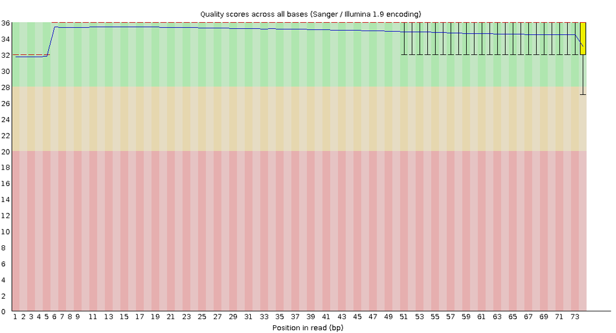

After trimming:

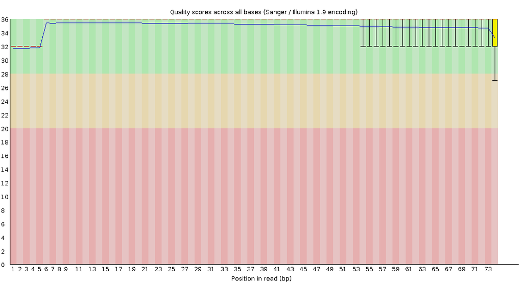

**Read 2**  
Before trimming:

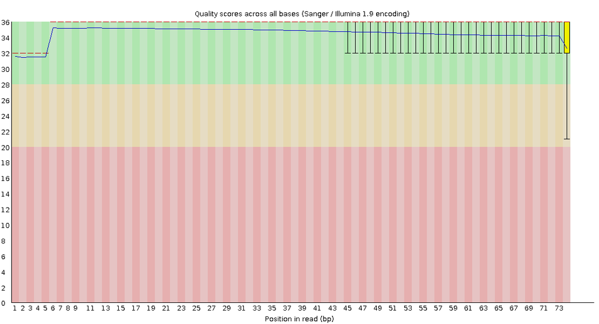

After trimming:

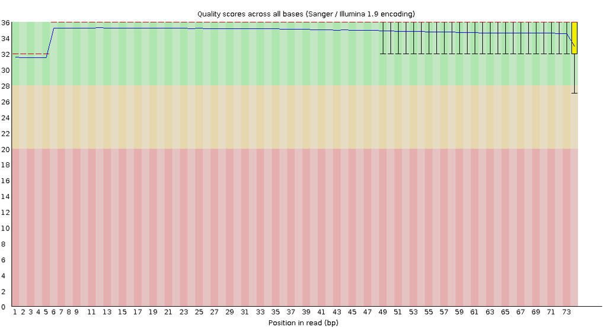